# Wrangling the Data

Kristin Gill, Larissa Neilson

1/24/2021

Sea Otter Strandings

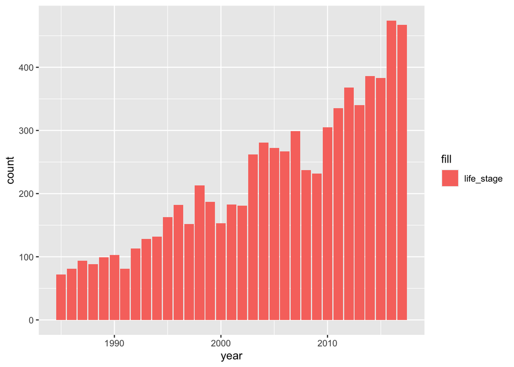

```r
sea_otter_data <- read_csv(here("data", "Table2_StrandedSeaOtter_byLifeStage_1985_2017.csv")) %>%
  clean_names() %>%
  pivot_longer(cols = 3:20, names_to = "life_stage", values_to = "count") %>%
  select(!total) %>%
  mutate(life_stage = case_when(
    life_stage == "pups_f" ~ "Pups:female",
    life_stage == "juvenile_f" ~ "Juvenile:female",
    life_stage == "sub_adult_f" ~ "Subadult:female",
    life_stage == "adult_f" ~ "Adult:female",
    life_stage == "old_adult_f" ~ "OldAdult:female",
    life_stage == "unknown_f" ~ "Unknown:female",
    life_stage == "pups_m" ~ "Pups:male",
    life_stage == "juvenile_m" ~ "Juvenile:male",
    life_stage == "sub_adult_m" ~ "Subadult:male",
    life_stage == "adult_m" ~ "Adult:male",
    life_stage == "old_adult_m" ~ "OldAdult:male",
    life_stage == "unknown_m" ~ "Unknown:male",
    life_stage == "pups_u" ~ "Pups:unknown",
    life_stage == "juvenile_u" ~ "Juvenile:unknown",
    life_stage == "sub_adult_u" ~ "Subadult:unknown",
    life_stage == "adult_u" ~ "Adult:unknown",
    life_stage == "old_adult_u" ~ "OldAdult:unknown",
    life_stage == "unknown_u" ~ "Unknown:unknown"
  )) %>%
  separate(life_stage, c("life_stage", "sex"))

ggplot(data = sea_otter_data, aes(x = year,
                                  y = count)) +
      geom_col(aes(fill = "life_stage"))
```

Sea Otter Annual Census

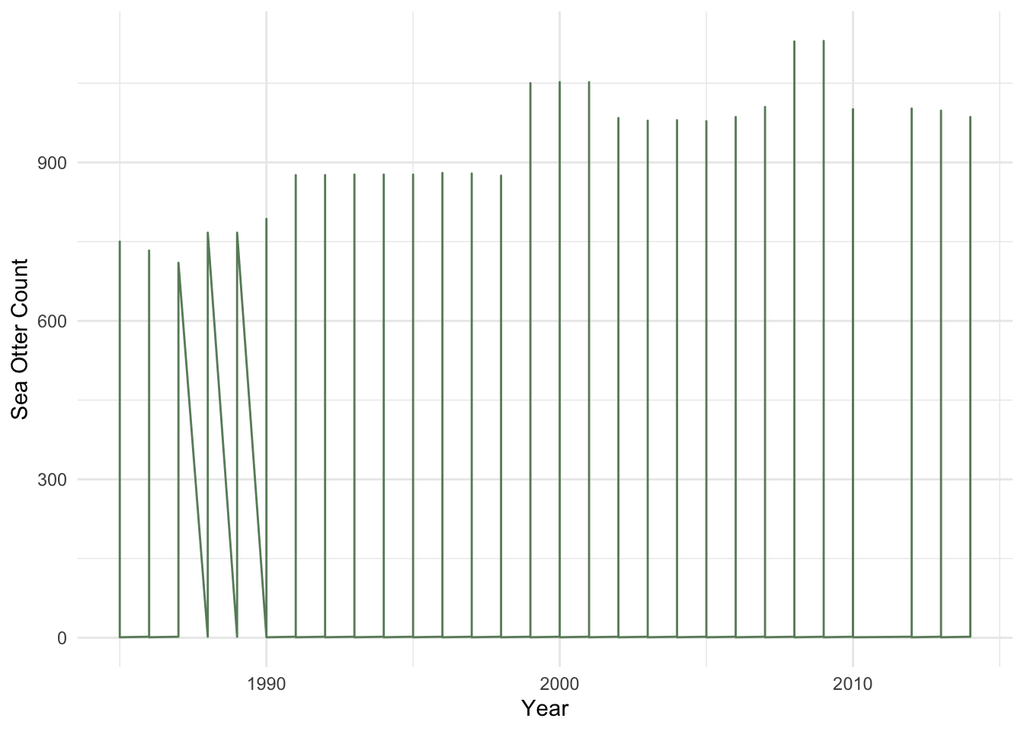

```r
census_sea_otter <- read_csv(here("data", "AnnualCaliforniaSeaOtter_Census_summary_1985_2014.csv")) %>%
  clean_names() %>%
  mutate(zone_code = case_when(
    zone_code == "b" ~ "Bay or Slough",
    zone_code == "n" ~ "Nearshore",
    zone_code == "o" ~ "Offshore",
    zone_code == "w" ~ "Way Offshore"
  ))

sea_otter_pop <- census_sea_otter %>%
  select(year, zone_code) %>%
  count(year, zone_code)

ggplot(data = sea_otter_pop, aes(x = year,
                                             y = n)) +
      geom_line(color = "darkseagreen4") +
      labs(x = "Year",
           y = "Sea Otter Count") +
      theme_minimal()
```

```r
#sea_otter_pop[is.na(sea_otter_pop)] <- 0

#sea_otter_pop %>%
#  ungroup()
```

Stranded Sea Otter by Geographic Location

```r
geog_sea_otter <- read_csv(here("data", "Table1_StrandedSeaOtter_byGeographicAreas_1985_2017.csv")) %>%
  clean_names() %>%
  select(!total_strandings) %>%
  pivot_longer(cols = 2:15, names_to = "location", values_to = "count") %>%
  mutate(year = as.character(year)) %>%
  mutate(location = case_when(
    location == "north_of_pigeon_pt" ~ "North of Pigeon Point",
    location == "pigeon_pt_to_capitola" ~ "Pigeon Point to Capitola",
    location == "capitola_to_seaside" ~ "Capitola to Seaside",
    location == "seaside_to_pt_lobos" ~ "Seaside to Point Lobos",
    location == "pt_lobos_to_pt_sur" ~ "Point Lobos to Point Sur",
    location == "pr_sur_to_dolan_rock" ~ "Point Sur to Dolan Rock",
    location == "dolan_rock_to_c_san_martin" ~ "Dolan Rock to Cape San Martin",
    location == "c_san_martin_to_san_simeon_point" ~ "Cape San Martin to San Simeon Point",
    location == "san_simeon_pt_to_cayucos" ~ "San Simeon Point to Cayucos",
    location == "cayucos_to_hazard_canyon" ~ "Cayucos to Hazard Canyon",
    location == "hazard_canyon_to_pismo_beach" ~ "Hazard Canyon to Pismo Beach",
    location == "pismo_beach_to_point_sal" ~ "Pismo Beach to Point Sal",
    location == "pt_sal_to_pt_conception" ~ "Point Sal to Point Conception",
    location == "se_of_pt_conception" ~ "Southeast of Point Conception"
  )) %>%
  drop_na
```

Stranded Sea Otter by Year and Month

```r
pop_sea_otter <- read_csv(here("data", "Table3_StrandedSeaOtter_byYearAndMonth_1985_2017.csv")) %>%
  clean_names() %>%
  select(!total) %>%
  pivot_longer(cols = 3:14, names_to = "month", values_to = "count")
```

Sea otter Linear Density

```r
locations_sea_otters <- read_sf(here("data", "shapefile_2019", "Census_sum_2019.shp")) %>%
  clean_names() %>%
  mutate_at(vars(lin_dens), funs(round(.,0)))


st_crs(locations_sea_otters)
```

[output not shown]

```r
california_cities <- read_sf(here("data", "tl_2016_06_place.shp")) %>%
  clean_names() %>%
  filter(namelsad == c("Santa Cruz", "Capitola", "Seascape", "Point Lobos", "Cayucos", "Watsonville", "Monterrey", "Carmel", "Santa Barbara"))

st_crs(california_cities)
```

```
## Coordinate Reference System:
##   User input: NAD83
##   wkt:
## GEOGCRS["NAD83",
##     DATUM["North American Datum 1983",
##         ELLIPSOID["GRS 1980",6378137,298.257222101,
##             LENGTHUNIT["metre",1]]],
##     PRIMEM["Greenwich",0,
##         ANGLEUNIT["degree",0.0174532925199433]],
##     CS[ellipsoidal,2],
##         AXIS["latitude",north,
##             ORDER[1],
##             ANGLEUNIT["degree",0.0174532925199433]],
##         AXIS["longitude",east,
##             ORDER[2],
##             ANGLEUNIT["degree",0.0174532925199433]],
##     ID["EPSG",4269]]
```

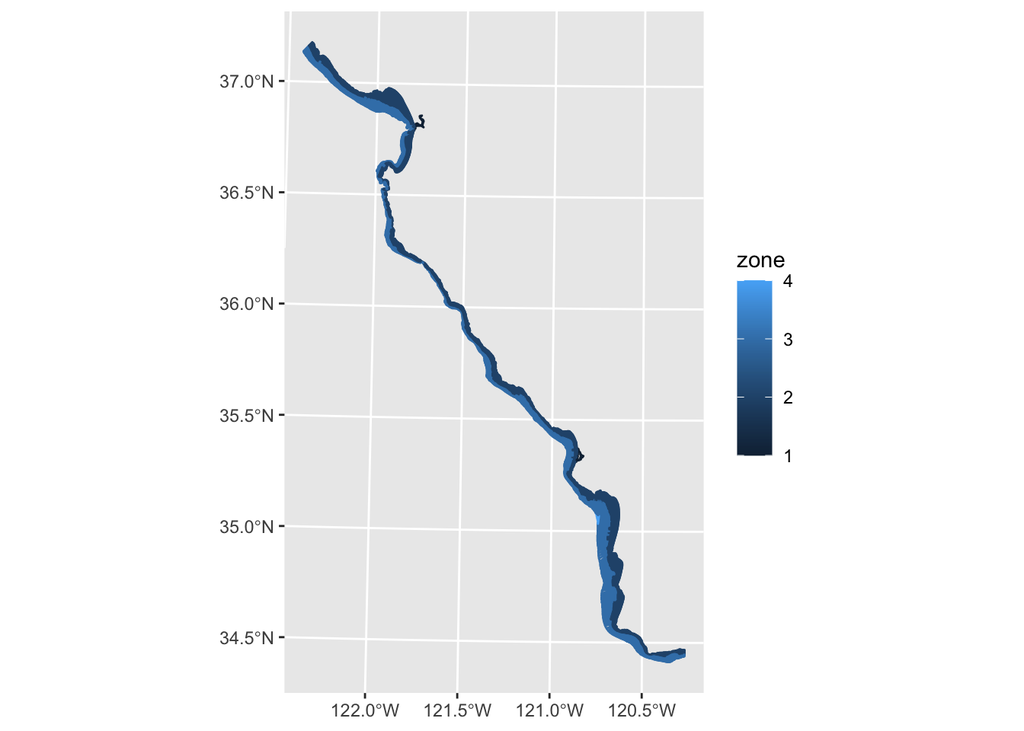

```r
ggplot() +
  geom_sf(data = locations_sea_otters, aes(color = zone)) +
  geom_sf(data = california_cities)
```

```r
tmap_mode("view")

tm_shape(locations_sea_otters) +
  tm_polygons("lin_dens", border.alpha = 0) +
  tm_fill("lin_dens") +
  tm_borders(alpha = 0)
```

[interactive chart not shown]

```r
pal <- brewer.pal(6,"BuGn")
pal
```

```
## [1] "#EDF8FB" "#CCECE6" "#99D8C9" "#66C2A4" "#2CA25F" "#006D2C"
```

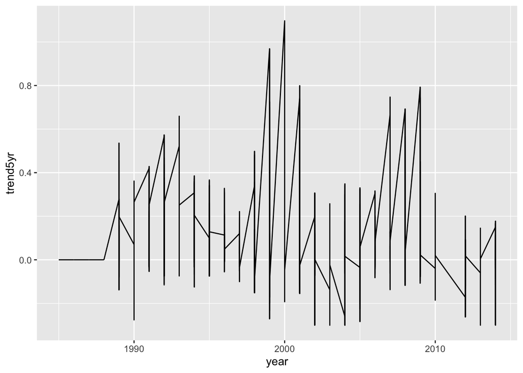

```r
# graphing the 5-year trend

ggplot(data = census_sea_otter, aes(x = year,
                                    y = trend5yr)) +
  geom_line()
```

## Summary

This app helps visualize Southern Sea Otter stranding and linear density data. The data is from the U.S. Geological Survey.

```r
#![Southern Sea Otter Range. Image: U.S. Fish and Wildlife](Sea_Otter_Population_Range.png)

#![Sea Otters! Image: Public Domain](otters.jpg)
```

**Data Citation Annual Sea Otter Census:** Yee, J.L., and Tinker, M.T., 2018, Annual California Sea Otter Census, 1985-2014:U.S. Geological Survey data release.

**Data Citation Sea Otter Strandings:** Hatfield, B.B., Harris, M.D., Young, C., Ames, J.A., and Tinker, M.T., 2018, Summary of stranded southern sea otters, 1985-2017 (ver. 2.0, September 2018): U.S. Geological Survey data release, https://doi.org/10.5066/F71J98P4."